# RST Data Annual QC

Published

August 12, 2026

```r
library(tidyverse)
library(lubridate)
library(here)
library(glue)
library(DT)

# Load package data (works from source or installed)
if (file.exists(here::here("DESCRIPTION"))) {
  devtools::load_all(here::here(), quiet = TRUE)
} else {
  library(SRJPEdata)
}

source(here::here("data-raw", "qc", "qc_helpers.R"))

review_run_year <- params$review_run_year
```

## Overview

Reviewing RST catch and trap data. Run year being reviewed: **2026**.

Data sources: `rst_catch`, `rst_trap`, `weekly_juvenile_abundance_catch_data`, `years_to_exclude_rst_data`.

RST catch records by stream and site

[output not shown]

## Check 1 (warning): Fork Length — High NA Rate

Flag stream/site/run_years where >95% of records have no fork length recorded and total records exceed 50. Indicates a season where measurements were not taken.

```r
fl_na_all <- rst_catch |>
  filter(!is.na(date)) |>
  mutate(run_year = as_run_year(date)) |>
  group_by(stream, site, run_year) |>
  summarise(
    n_records    = n(),
    n_na_fl      = sum(is.na(fork_length)),
    pct_na_fl    = round(mean(is.na(fork_length)) * 100, 1),
    .groups      = "drop"
  )

fl_na_check <- fl_na_all |>
  filter(pct_na_fl > 95, n_records > 50)

new_fl_na <- log_issues(
  fl_na_check |>
    mutate(
      data_type   = "rst",
      issue_type  = "high_na_rate",
      field       = "fork_length",
      severity    = "moderate",
      alert_level = "warning",
      description = glue("{n_na_fl} of {n_records} records ({pct_na_fl}%) have no fork length in run year {run_year} at {site} ({stream})")
    )
)
```

```
  All 4 issue(s) already in log.
```

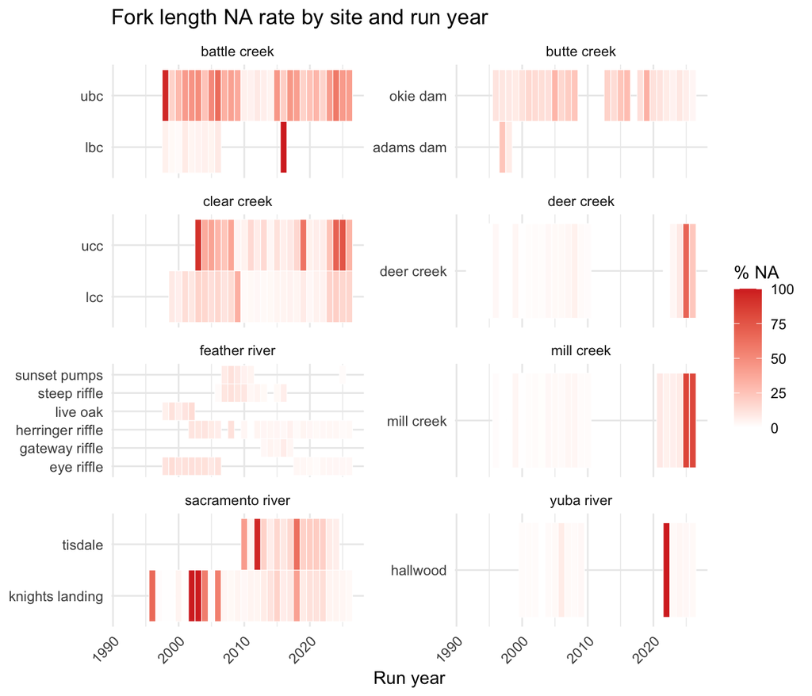

4 site/run-year combination(s) flagged.

## Check 2 (warning): Fork Length — Implausible Values

Flag records where `fork_length < 20mm` or `fork_length > 200mm`. These are biologically implausible for juvenile chinook at an RST.

```r
fl_impl_all <- rst_catch |>
  filter(!is.na(fork_length), fork_length > 0) |>
  mutate(run_year = as_run_year(date)) |>
  mutate(implausible = fork_length < 20 | fork_length > 200) |>
  group_by(stream, site, run_year) |>
  summarise(
    n_evaluated  = n(),
    n_records    = sum(implausible),
    min_fl       = suppressWarnings(min(fork_length[implausible], na.rm = TRUE)),
    max_fl       = suppressWarnings(max(fork_length[implausible], na.rm = TRUE)),
    .groups      = "drop"
  )

fl_impl_check <- fl_impl_all |> filter(n_records > 0)

new_fl_impl <- log_issues(
  fl_impl_check |>
    mutate(
      data_type   = "rst",
      issue_type  = "implausible_value",
      field       = "fork_length",
      severity    = "critical",
      alert_level = "warning",
      description = glue("{n_records} record(s) with fork_length <20mm or >200mm in run year {run_year} at {site} ({stream}). Range of flagged values: [{min_fl}, {max_fl}]mm")
    )
)
```

```
  All 64 issue(s) already in log.
```

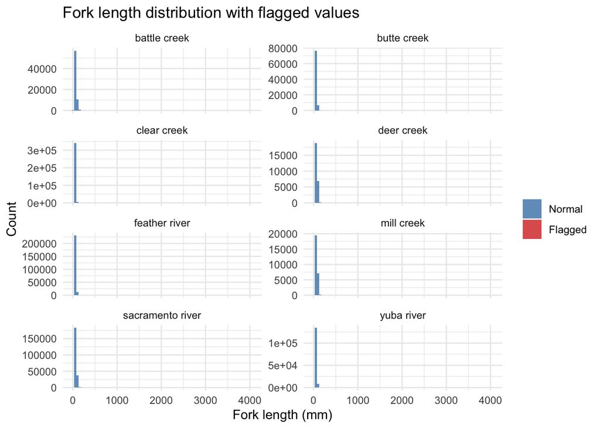

64 site/run-year combination(s) flagged.

## Check 3a (error): Catch — Extreme Annual Totals

```r
annual_catch <- rst_catch |>
  filter(!is.na(date), !is.na(count)) |>
  mutate(run_year = as_run_year(date)) |>
  group_by(stream, site, run_year) |>
  summarise(total_catch = sum(count, na.rm = TRUE), .groups = "drop")

site_stats <- annual_catch |>
  group_by(stream, site) |>
  summarise(
    n_years      = n(),
    median_catch = median(total_catch),
    .groups      = "drop"
  ) |>
  filter(n_years >= 5, median_catch > 0)

annual_catch_eval <- annual_catch |> inner_join(site_stats, by = c("stream", "site"))

catch_extreme <- annual_catch_eval |>
  filter(total_catch > 4 * median_catch)

new_catch_extreme <- log_issues(
  catch_extreme |>
    mutate(
      n_records   = 1L,
      data_type   = "rst",
      issue_type  = "extreme_value",
      field       = "count",
      severity    = "minor",
      alert_level = "error",
      description = glue("Total catch of {total_catch} in run year {run_year} at {site} ({stream}) is {round(total_catch / median_catch, 1)}x the site median ({median_catch})")
    )
)
```

```
  All 47 issue(s) already in log.
```

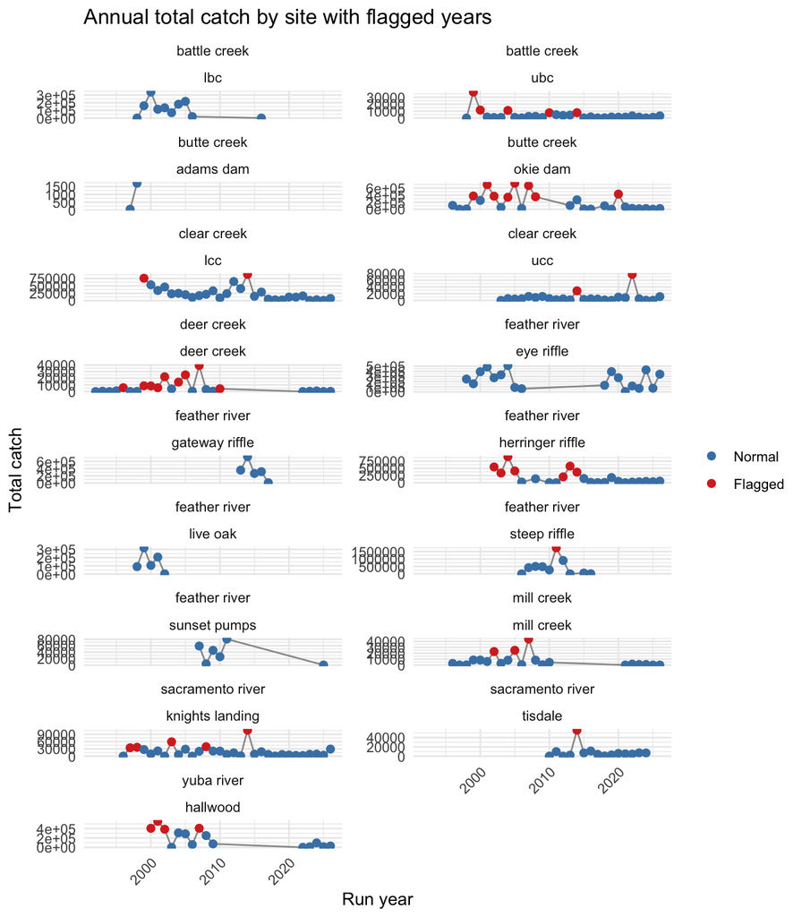

47 site/run-year combination(s) flagged.

### Check 3b (Warning) Check Weekly Extreme Values

Flags individual weeks (rather than annual totals) where catch is unusually high relative to that site’s own weekly distribution. We use the same metric 4X medium weekly catch. This check catches weeks with a single anomalous spike that might get averaged out of an annual total.

```r
weekly_catch_stats <- weekly_juvenile_abundance_catch_data |>
  filter(!is.na(count)) |>
  group_by(stream, site) |>
  mutate(
    median_weekly_count = median(count, na.rm = TRUE),
    mediumX4 = median_weekly_count * 4
  ) |>
  ungroup()

weekly_extreme_all <- weekly_catch_stats |>
  group_by(stream, site, run_year) |>
  summarise(
    n_evaluated = n(),
    n_failed    = sum(count > mediumX4),
    max_count   = max(count),
    greater_than_four_x_medium = first(mediumX4),
    .groups     = "drop"
  )

weekly_extreme <- weekly_extreme_all |> filter(n_failed > 0)

new_weekly_extreme <- log_issues(
  weekly_extreme |>
    mutate(
      n_records   = n_failed,
      data_type   = "rst",
      issue_type  = "extreme_value",
      field       = "count_weekly",
      severity    = "minor",
      alert_level = "warning",
      description = glue("{n_failed} week(s) with catch above 4X medium ({round(greater_than_four_x_medium)}) in run year {run_year} at {site} ({stream}). Max weekly catch: {max_count}")
    )
)
```

```
  All 254 issue(s) already in log.
```

254 site/run-year combination(s) flagged.

## Check 4 (error): Season Coverage — Low Sampling Effort

Note - These years are removed from the modeling dataset but the purpose of this check is to talk to the data collectors to ensure we are not missing data and the low sampling effort is accurate and the automatic fix to remove is correct.

```r
weeks_in_window <- weekly_juvenile_abundance_catch_data |>
  filter(week %in% c(45:53, 1:22), !is.na(count)) |>
  group_by(stream, site, run_year) |>
  summarise(weeks_sampled = n_distinct(week), .groups = "drop")

excluded_lookup <- rst_model_years |>
  filter(exclude == TRUE) |>
  distinct(stream, site, run_year) |>
  mutate(already_excluded = TRUE)

low_effort <- weeks_in_window |>
  filter(weeks_sampled < 3) |>
  left_join(excluded_lookup, by = c("stream", "site", "run_year")) |>
  mutate(already_excluded = replace_na(already_excluded, FALSE)) |>
  filter(already_excluded == FALSE)

new_low_effort <- log_issues(
  low_effort |>
    mutate(
      n_records   = weeks_sampled,
      data_type   = "rst",
      issue_type  = "low_sampling_effort",
      field       = "weeks_sampled",
      severity    = "moderate",
      alert_level = "error",
      description = glue("Only {weeks_sampled} week(s) sampled in BTSPAS window for run year {run_year} at {site} ({stream}). Already excluded from modeling: {already_excluded}")
    )
)
```

```
  No issues detected for this check.
```

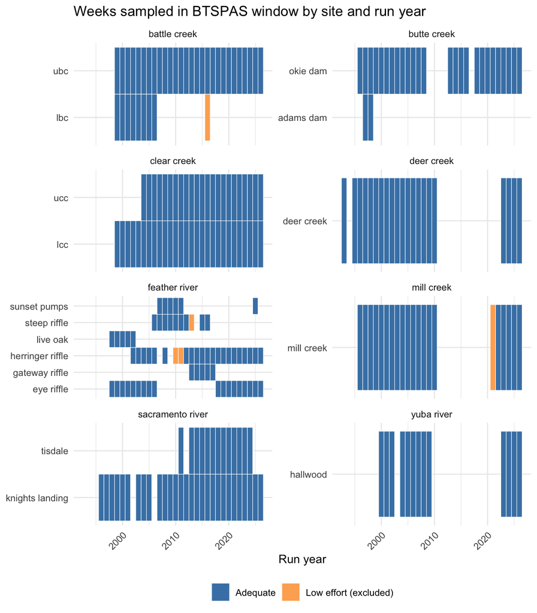

No issues detected.

## Issues Logged This Run

```
No new issues logged this run.
```

### All Open RST Issues

| log_id | date_identified | stream | site | run_year | issue_type | field | severity | alert_level | description | reviewer_notes |
| --- | --- | --- | --- | --- | --- | --- | --- | --- | --- | --- |
| rst__battle_creek__ubc__1999__extreme_value__count | 2026-08-12 | battle creek | ubc | 1999 | extreme_value | count | minor | error | Total catch of 37495 in run year 1999 at ubc (battle creek) is 24.6x the site median (1523) |  |
| rst__battle_creek__ubc__2000__extreme_value__count | 2026-08-12 | battle creek | ubc | 2000 | extreme_value | count | minor | error | Total catch of 11558 in run year 2000 at ubc (battle creek) is 7.6x the site median (1523) |  |
| rst__battle_creek__ubc__2004__extreme_value__count | 2026-08-12 | battle creek | ubc | 2004 | extreme_value | count | minor | error | Total catch of 11010 in run year 2004 at ubc (battle creek) is 7.2x the site median (1523) |  |
| rst__battle_creek__ubc__2010__extreme_value__count | 2026-08-12 | battle creek | ubc | 2010 | extreme_value | count | minor | error | Total catch of 7605 in run year 2010 at ubc (battle creek) is 5x the site median (1523) |  |
| rst__battle_creek__ubc__2014__extreme_value__count | 2026-08-12 | battle creek | ubc | 2014 | extreme_value | count | minor | error | Total catch of 7737 in run year 2014 at ubc (battle creek) is 5.1x the site median (1523) |  |
| rst__butte_creek__okie_dam__1999__extreme_value__count | 2026-08-12 | butte creek | okie dam | 1999 | extreme_value | count | minor | error | Total catch of 375222 in run year 1999 at okie dam (butte creek) is 4.6x the site median (81964.5) |  |
| rst__butte_creek__okie_dam__2001__extreme_value__count | 2026-08-12 | butte creek | okie dam | 2001 | extreme_value | count | minor | error | Total catch of 696955 in run year 2001 at okie dam (butte creek) is 8.5x the site median (81964.5) |  |
| rst__butte_creek__okie_dam__2002__extreme_value__count | 2026-08-12 | butte creek | okie dam | 2002 | extreme_value | count | minor | error | Total catch of 369493 in run year 2002 at okie dam (butte creek) is 4.5x the site median (81964.5) |  |
| rst__butte_creek__okie_dam__2004__extreme_value__count | 2026-08-12 | butte creek | okie dam | 2004 | extreme_value | count | minor | error | Total catch of 339706 in run year 2004 at okie dam (butte creek) is 4.1x the site median (81964.5) |  |
| rst__butte_creek__okie_dam__2005__extreme_value__count | 2026-08-12 | butte creek | okie dam | 2005 | extreme_value | count | minor | error | Total catch of 736669 in run year 2005 at okie dam (butte creek) is 9x the site median (81964.5) |  |

[output cut: 359 more lines]